# Google Data Analytics : Case Study 1

Tomas Kejha

2022-10-30

# Introduction of the company

**Cyclistic** is a bike-share company in Chicago. Their bike-share program features more than 5,800 bicycles and 600 docking stations. The company distinguishes itself from its competitors by offering reclining bikes, hand tricycles, and cargo bikes providing an opportunity for people with disabilities.

The company offers three pricing plans:

- single-ride passes
- full-day passes
- annual membership

Customers who purchase *single-ride* or *full-day* passes are reffered to as `casual riders` and customers who purchase *annual membership* are reffered to as `Cyclistic members`.

## Business Task

Annual members are much more profitable and the director of marketing, Lily Moreno, believes that maximizing the number of annual members will be the key to future growth. Moreno also believes that there is a very good chance to convert casual riders into members rather than creating a marketing campaign that targets all-new customers.

**Goal:**

- Design marketing strategies aimed at converting casual riders into annual members

**Answer following questions:**

- How do annual members and casual riders use Cyclistic bikes differently?
- Why would casual riders buy Cyclistic annual memberships?
- How can Cyclistic use digital media to influence casual riders to become members?

## My Task

As a junior data analyst, you have been asked to analyze data to help with the solution of the the first question: how do annual members and casual riders use Cyclistic bikes differently.

## Data Used for the Analysis

I examined 12 months of data reaching from the 2<sup>nd</sup> quartile of 2019 to the 1<sup>st</sup> quartile of 2020.

**Data source**: [divvy_tripdata](https://divvy-tripdata.s3.amazonaws.com/index.html)

# Question 1 : How do annual members and casual riders use Cyclistic bikes differently?

## Loading Packages

```r
library(tidyverse)
library(lubridate)
```

```r
library(ggplot2)
library(skimr)
library(janitor)
```

## Collecting Data

```r
q2_2019 <- read_csv("C:\\Users\\tomas\\OneDrive\\Plocha\\Google Data Analytics Certificate\\CaseStudies\\Track_1_CaseStudy_1\\Divvy_Trips_2019_Q2.csv")
q3_2019 <- read_csv("C:\\Users\\tomas\\OneDrive\\Plocha\\Google Data Analytics Certificate\\CaseStudies\\Track_1_CaseStudy_1\\Divvy_Trips_2019_Q3.csv")
q4_2019 <- read_csv("C:\\Users\\tomas\\OneDrive\\Plocha\\Google Data Analytics Certificate\\CaseStudies\\Track_1_CaseStudy_1\\Divvy_Trips_2019_Q4.csv")
q1_2020 <- read_csv("C:\\Users\\tomas\\OneDrive\\Plocha\\Google Data Analytics Certificate\\CaseStudies\\Track_1_CaseStudy_1\\Divvy_Trips_2020_Q1.csv")
```

## Cleaning Data

### Renaming columns to be consistent with q1_2020

```r
q4_2019 <- rename(q4_2019,
                  ride_id = trip_id,
                  rideable_type = bikeid,
                  started_at = start_time,
                  ended_at = end_time,
                  start_station_name = from_station_name,
                  start_station_id = from_station_id,
                  end_station_name = to_station_name,
                  end_station_id = to_station_id,
                  member_casual = usertype)
q3_2019 <- rename(q3_2019,
                  ride_id = trip_id,
                  rideable_type = bikeid,
                  started_at = start_time,
                  ended_at = end_time,
                  start_station_name = from_station_name,
                  start_station_id = from_station_id,
                  end_station_name = to_station_name,
                  end_station_id = to_station_id,
                  member_casual = usertype)
q2_2019 <- rename(q2_2019,
                  ride_id = "01 - Rental Details Rental ID",
                  rideable_type = "01 - Rental Details Bike ID",
                  started_at = "01 - Rental Details Local Start Time",
                  ended_at = "01 - Rental Details Local End Time",
                  start_station_name = "03 - Rental Start Station Name",
                  start_station_id = "03 - Rental Start Station ID",
                  end_station_name = "02 - Rental End Station Name",
                  end_station_id = "02 - Rental End Station ID",
                  member_casual = "User Type")
```

### Converting ‘ride_id’ and ‘rideable_type’ in 2019 to ‘character’ to match 2020

```r
q4_2019 <- mutate(q4_2019, ride_id = as.character(ride_id), rideable_type = as.character(rideable_type))
q3_2019 <- mutate(q3_2019, ride_id = as.character(ride_id), rideable_type = as.character(rideable_type))
q2_2019 <- mutate(q2_2019, ride_id = as.character(ride_id), rideable_type = as.character(rideable_type))
```

### Combining data frames

```r
all_trips <- bind_rows(q2_2019,q3_2019,q4_2019,q1_2020)
```

### Removing data points that were not used since 2020

```r
all_trips <- all_trips %>%
  select(-c(start_lat,start_lng, end_lat, end_lng,birthyear, gender,"01 - Rental Details Duration In Seconds Uncapped", "05 - Member Details Member Birthday Year", "Member Gender", "tripduration"))
```

### Renaming ‘member_casual’ entries

```r
all_trips <- all_trips %>%
  mutate(member_casual = recode(member_casual, "Subscriber" = "member", "Customer" = "casual"))
```

### Adding time-related collumns

```r
all_trips$date <- as.Date(all_trips$started_at)
all_trips$month <- format(as.Date(all_trips$date), "%m")
all_trips$day <- format(as.Date(all_trips$date), "%d")
all_trips$year <- format(as.Date(all_trips$date), "%Y")
all_trips$day_of_week <- format(as.Date(all_trips$date), "%A")

all_trips$ride_length <- difftime(all_trips$ended_at, all_trips$started_at)
```

### Converting ‘ride_length’ to numeric

```r
all_trips$ride_length <- as.numeric(as.character(all_trips$ride_length))
```

### Removing irrelevant entries

```r
all_trips_v2 <- all_trips[!(all_trips$start_station_name == "HQ QR" | all_trips$ride_length < 0),]
```

## Descriptive Analysis

### Analysing ‘ride_length’

```r
all_trips_v2 %>%
  summarise(average_ride_length = mean(ride_length),
            median_ride_length = median(ride_length), # the middle number
            longest_ride_length = max(ride_length),
            shortest_ride_length = min(ride_length))
```

```
## # A tibble: 1 × 4
##   average_ride_length median_ride_length longest_ride_length shortest_ride_len…¹
##                 <dbl>              <dbl>               <dbl>               <dbl>
## 1               1479.                712             9387024                   1
## # … with abbreviated variable name ¹shortest_ride_length
```

### Comparing members and casual users ride length

```r
all_trips_v2 %>%
  group_by(member_casual) %>%
  summarise(average_ride_length = mean(ride_length),
            median_ride_length = median(ride_length), # the middle number
            longest_ride_length = max(ride_length),
            shortest_ride_length = min(ride_length))
```

```
## # A tibble: 2 × 5
##   member_casual average_ride_length median_ride_length longest_ride_le…¹ short…²
##   <chr>                       <dbl>              <dbl>             <dbl>   <dbl>
## 1 casual                      3553.               1546           9387024       2
## 2 member                       850.                589           9056634       1
## # … with abbreviated variable names ¹longest_ride_length, ²shortest_ride_length
```

### Correcting the order of day_of_week

```r
all_trips_v2$day_of_week <- ordered(all_trips_v2$day_of_week, levels = c("Monday", "Tuesday", "Wednesday", "Thursday", "Friday", "Saturday", "Sunday"))
```

### Average ride time by each day for members and casual users

```r
all_trips_v2 %>%
  group_by(day_of_week, member_casual) %>%
  summarise(average_length_of_ride = mean(ride_length),
            number_of_rides = n()) %>%
  arrange(day_of_week)
```

```
## # A tibble: 14 × 4
## # Groups:   day_of_week [7]
##    day_of_week member_casual average_length_of_ride number_of_rides
##    <ord>       <chr>                          <dbl>           <int>
##  1 Monday      casual                         3372.          103296
##  2 Monday      member                          843.          472196
##  3 Tuesday     casual                         3596.           90510
##  4 Tuesday     member                          826.          508445
##  5 Wednesday   casual                         3719.           92457
##  6 Wednesday   member                          824.          500329
##  7 Thursday    casual                         3683.          102679
##  8 Thursday    member                          824.          484177
##  9 Friday      casual                         3774.          122404
## 10 Friday      member                          825.          452790
## 11 Saturday    casual                         3332.          209543
## 12 Saturday    member                          969.          287958
## 13 Sunday      casual                         3581.          181293
## 14 Sunday      member                          920.          267965
```

## Visualizating Data

### Length of rides

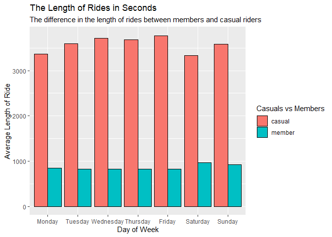

```r
all_trips_v2 %>%
  group_by(day_of_week, member_casual) %>%
  summarise(average_length_of_ride = mean(ride_length),
            number_of_rides = n()) %>%
  arrange(day_of_week) %>%
  ggplot(mapping = aes(x = day_of_week, y = average_length_of_ride, fill = member_casual)) + geom_col(position = "dodge", color = "black") +
  labs(title = "The Length of Rides in Seconds", subtitle = "The difference in the length of rides between members and casual riders", x = "Day of Week", y = "Average Length of Ride", fill = "Casuals vs Members")
```

### Number of Rides

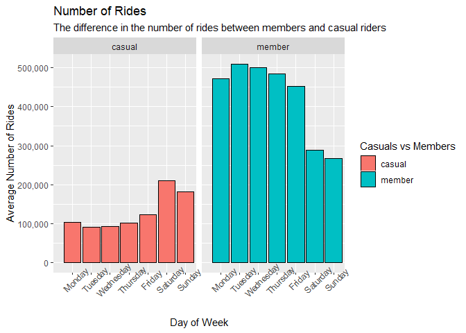

```r
all_trips_v2 %>%
  group_by(day_of_week, member_casual) %>%
  summarise(average_length_of_ride = mean(ride_length),
            number_of_rides = n()) %>%
  arrange(day_of_week) %>%
  ggplot(mapping = aes(x = day_of_week, y = number_of_rides, fill = member_casual)) + geom_col(color = "black") +
  facet_wrap(~member_casual) +
  labs(title = "Number of Rides", subtitle = "The difference in the number of rides between members and casual riders", x = "Day of Week", y = "Average Number of Rides", fill = "Casuals vs Members") +
  theme(axis.text.x = element_text(angle = 45)) + # changing the angle of x axis labels
  expand_limits( x = c(0,NA), y = c(0,NA)) +  # changes the outcome
  scale_y_continuous(labels = scales::comma)  # of y to readable numbers
```

## Conclusion

Analyzing and visualizing the data provided us with two main differences between casual riders and members:

1. Casual riders use bikes for significantly longer period of time compared to members
2. Casual riders do not rent bikes as often as members

The simple analysis has a potential to lead the marketing team to a data-driven decision. We have found out, that casual riders are much more likely to rent a bike for a longer duration of time which we can use to adjust the membership program so it is more lucrative for them to become members.

One of the options might be to provide a discount for future renting for every 10km a customer rides. Casual riders do not use the renting service that often but if the discount (or other benefits) was significant enough, they might be willing to become members.